# Introduction to Ecological Trajectory Analysis

## Trajectory centering

Trajectory centering removes differences in (e.g. initial or overall) *position* between trajectories, without changing their shape, to focus on the direction of temporal changes.

Trajectory centering is done using function `centerTrajectories()`:

```r
x_cent <- centerTrajectories(x)
```

The following trajectory plots show the effect of centering visually:

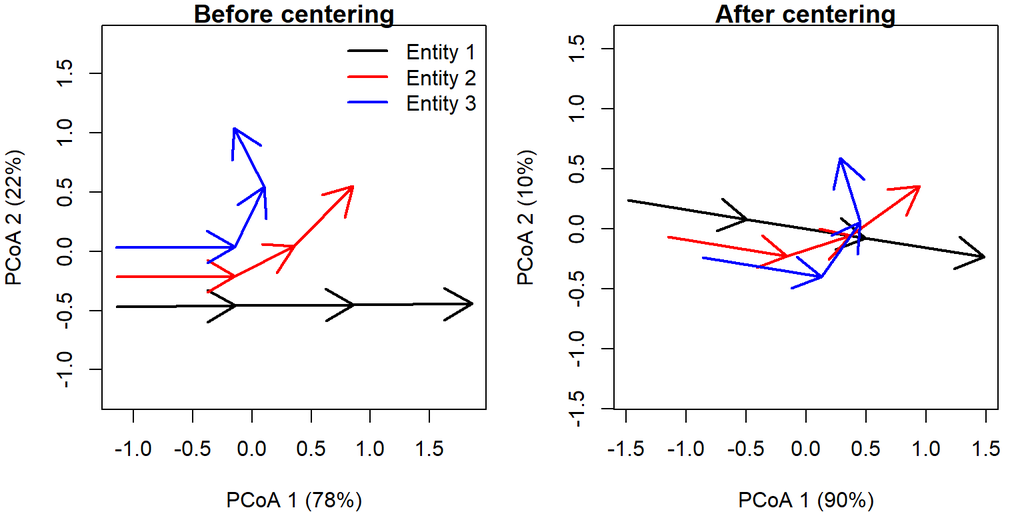

## Trajectory smoothing

Trajectories may contain variation that is considered *noise*, for whatever reason (e.g. measurement error). Similarly to univariate smoothing of temporal series, noise can be smoothed out in trajectory data.

Temporal smoothing of trajectories done using function `smoothTrajectories()`, which applies a multivariate moving average over each trajectory and uses a **Gaussian kernel** to specify average weights.

The following plots illustrate the effect of smoothing:

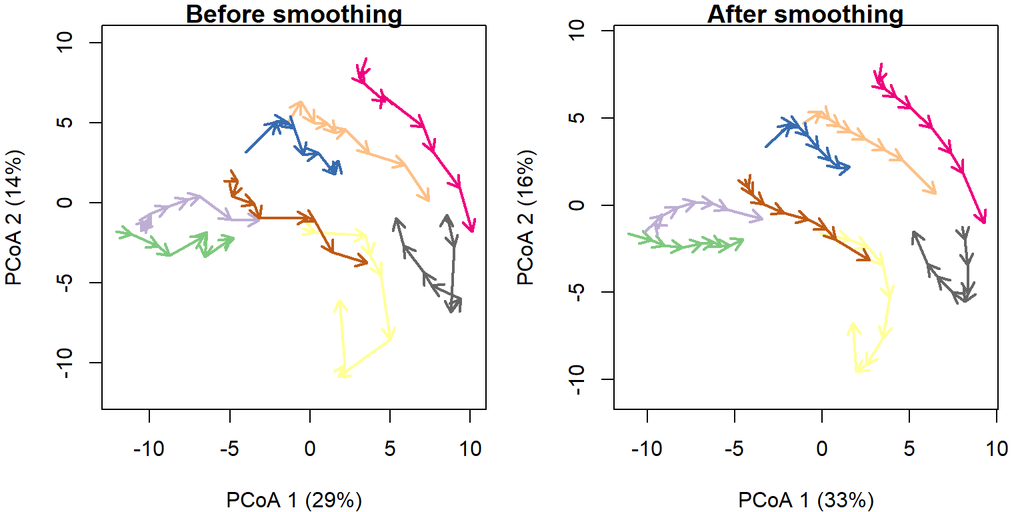

[figure not shown]

M.C. Escher - Dragon, 1952